# APRESENTAÇÃO_2_DE_MLG

ANTÔNIO VICTOR

# BANCO DE DADOS

```
## # A tibble: 195 × 13
##    dancab…¹ energia tonal…² sonor…³   fala acust…⁴ instr…⁵ vivac…⁶ valen…⁷   bpm
##       <dbl>   <dbl>   <dbl>   <dbl>  <dbl>   <dbl>   <dbl>   <dbl>   <dbl> <dbl>
##  1    0.803  0.624        7   -6.76 0.0477  0.451  7.34e-4  0.1     0.628   96.0
##  2    0.762  0.703       10   -7.95 0.306   0.206  0        0.0912  0.519  151.
##  3    0.261  0.0149       1  -27.5  0.0419  0.992  8.97e-1  0.102   0.0382  75.3
##  4    0.722  0.736        3   -6.99 0.0585  0.431  1.18e-6  0.123   0.582   89.9
##  5    0.787  0.572        1   -7.52 0.222   0.145  0        0.0753  0.647  155.
##  6    0.778  0.632        8   -6.42 0.125   0.0404 0        0.0912  0.827  141.
##  7    0.666  0.589        0   -8.40 0.324   0.555  0        0.114   0.776   75.0
##  8    0.922  0.712        7   -6.02 0.171   0.0779 3.96e-5  0.175   0.904  105.
##  9    0.794  0.659        7   -7.06 0.0498  0.143  2.24e-3  0.0944  0.308  112.
## 10    0.853  0.668        3   -7.00 0.447   0.263  0        0.104   0.745  158.
## # … with 185 more rows, 3 more variables: duracao_em_mls <dbl>,
## #   marcador_compasso <dbl>, gostou_ou_nao <dbl>, and abbreviated variable
## #   names ¹dancabilidade, ²tonalidade_key, ³sonoridade, ⁴acustica,
## #   ⁵instrumentabilidade, ⁶vivacidade_aovivo, ⁷valencia
```

## OS DADOS SÃO REFERENTES A QUE MÚSICAS O AUTOR GOSTOU, E ASSIM A ANÁLISE SERVIRÁ PARA ENTENDER QUAIS VARIÁVEIS MAIS INFLUENCIAM NO SEU GOSTO, ENTRE ELAS, TEMOS:

### **DANÇABILIDADE**

#### Descreve o quanto uma faixa é adequada para dançar com base em uma combinação de elementos musicais, incluindo andamento, estabilidade do ritmo, força da batida e regularidade geral. Um valor de 0 é menos dançável e 1 é o mais dançável.

### **ENERGIA**

#### A energia é uma medida de 0,0 a 1,0 e representa uma medida perceptiva de intensidade e atividade. Normalmente, as faixas energéticas parecem rápidas, altas e barulhentas. Por exemplo, death metal tem alta energia, enquanto um prelúdio de Bach pontua baixo na escala. Os recursos perceptivos que contribuem para esse atributo incluem faixa dinâmica, sonoridade percebida, timbre, taxa de início e entropia geral.

### **TONALIDADE_KEY**

#### A tonalidade em que a faixa está

### **SONORIDADE**

#### O volume geral de uma faixa em decibéis (dB)

### **FALA**

#### Detecta a presença de palavras faladas em uma faixa. Quanto mais exclusivamente semelhante à fala for a gravação (por exemplo, talk show, livro de áudio, poesia), mais próximo de 1,0 será o valor do atributo. Valores acima de 0,66 descrevem faixas que provavelmente são feitas inteiramente de palavras faladas. Valores entre 0,33 e 0,66 descrevem faixas que podem conter música e fala, seja em seções ou em camadas, incluindo casos como rap. Valores abaixo de 0,33 provavelmente representam música e outras faixas não semelhantes à fala.

### **ACUSTICA**

#### De 0 a 1. 1 representa alta confiança de que a faixa é acústica.

### **INSTRUMENTABILIDADE**

#### Prevê se uma faixa não contém vocais. Os sons “Ooh” e “aah” são tratados como instrumentais neste contexto. Faixas de rap ou palavras faladas são claramente “vocais”. Quanto mais próximo o valor da instrumentalidade estiver de 1,0, maior a probabilidade de a faixa não conter nenhum conteúdo vocal. Valores acima de 0,5 destinam-se a representar faixas instrumentais, mas a confiança é maior conforme o valor se aproxima de 1,0.

### **VIVACIDADE AO VIVO**

#### Detecta a presença de uma audiência na gravação. Valores mais altos de vivacidade representam uma probabilidade maior de que a faixa tenha sido tocada ao vivo. Um valor acima de 0,8 fornece uma forte probabilidade de que a faixa esteja ativa.

### **VALENCIA**

#### Uma medida de 0 a 1 que descreve a positividade musical transmitida por uma faixa. Faixas com alta valência soam mais positivas (por exemplo, alegres, alegres, eufóricas), enquanto faixas com baixa valência soam mais negativas (por exemplo, tristes, deprimidas, zangadas).

### **BPM**

#### O andamento geral estimado de uma faixa em batidas por minuto (BPM)

### **DURAÇÃO DA FAIXA EM MILISEGUNDOS**

### **MEDIDOR DE TEMPO NO COMPASSO**

# DADOS FALTANTES

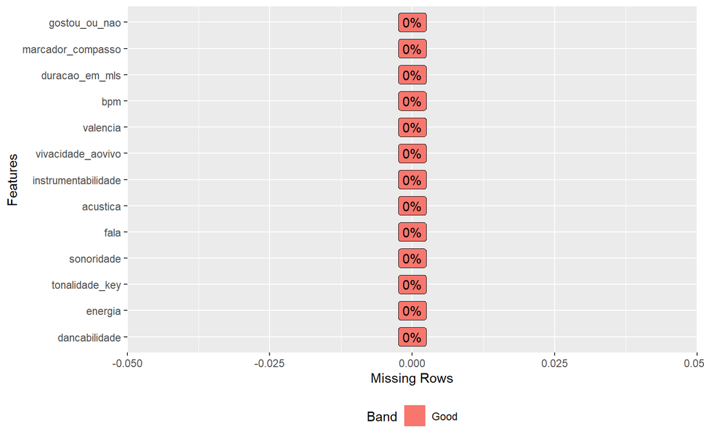

# CORRELAÇÃO E PROPORÇÃO

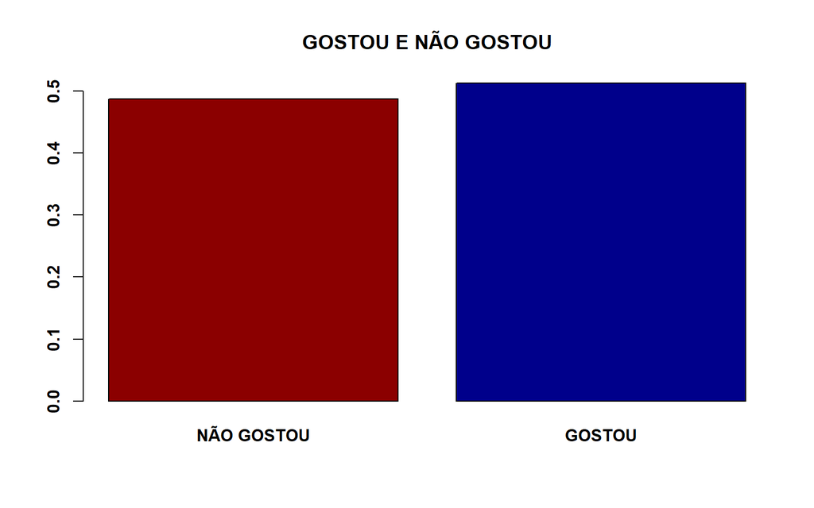

```
##
##   0   1
##  95 100
```

#### OBSERVE QUE AS VARIÁVEIS ESTÃO BEM DISTRIBUÍDAS.

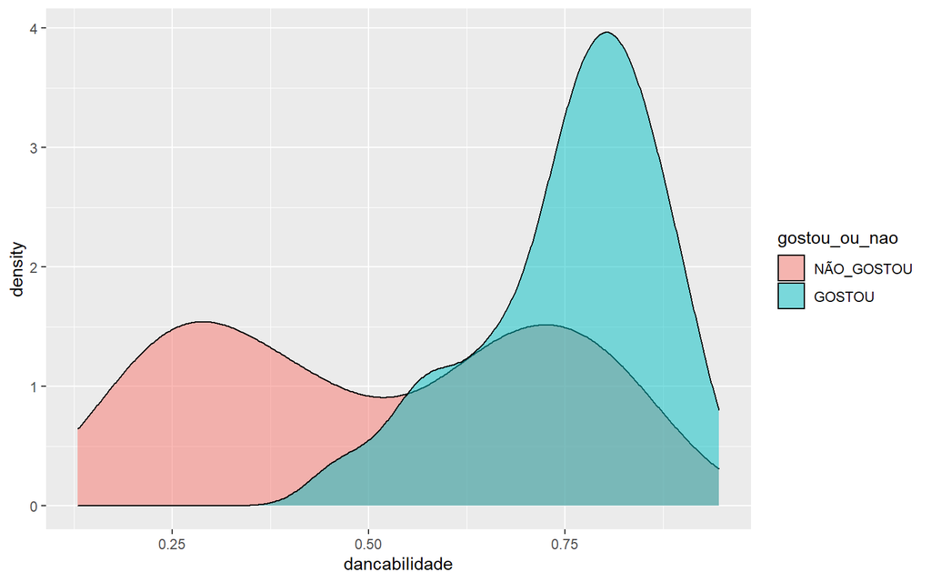

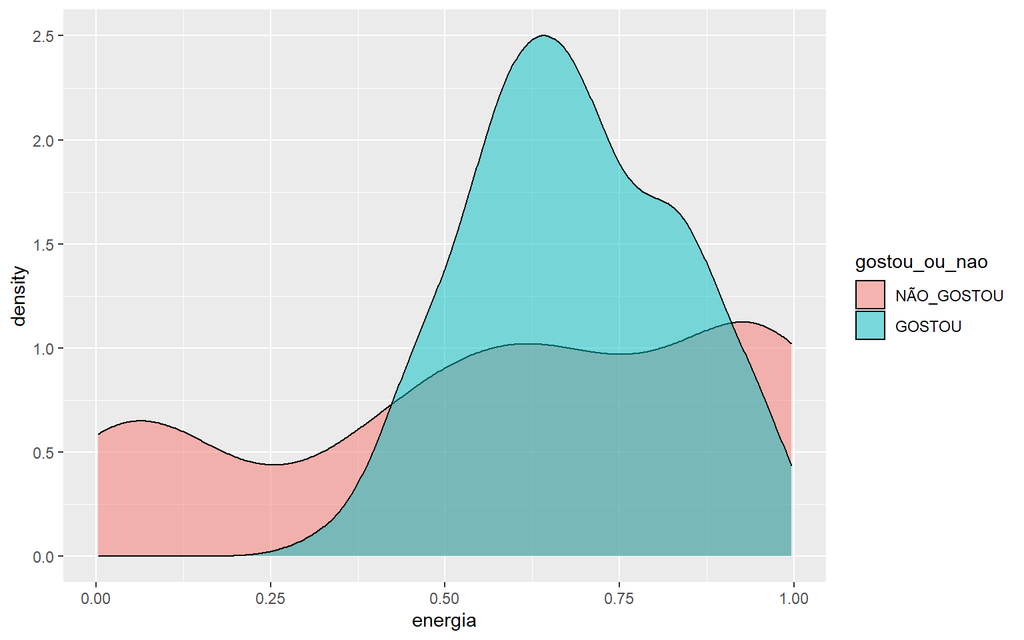

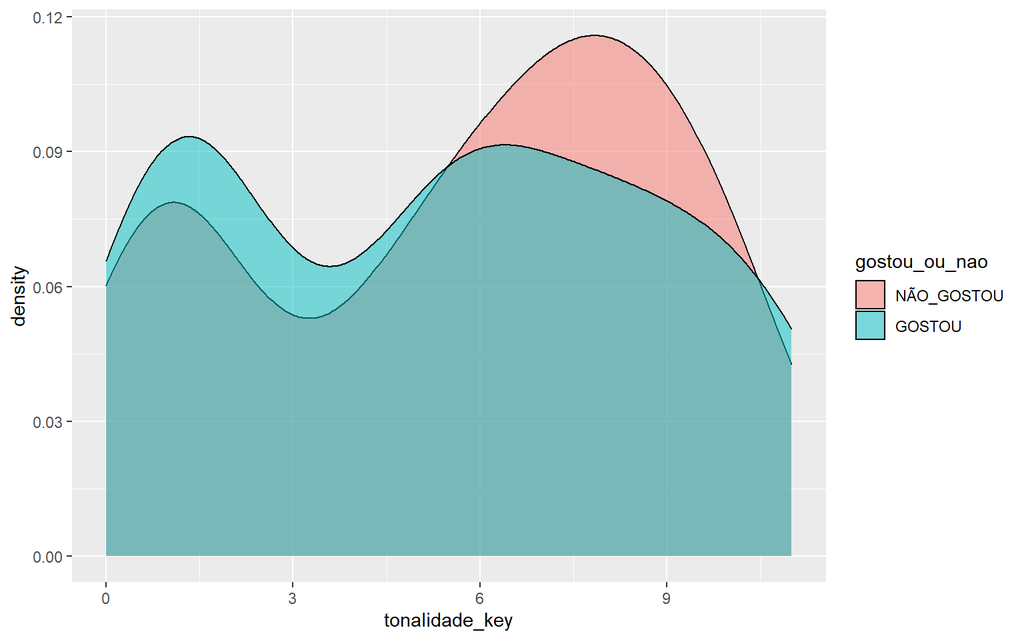

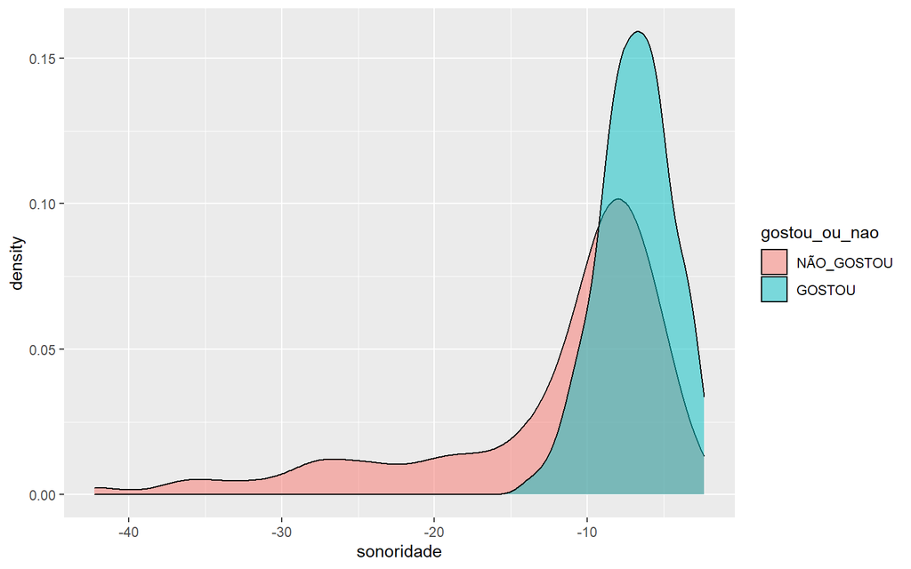

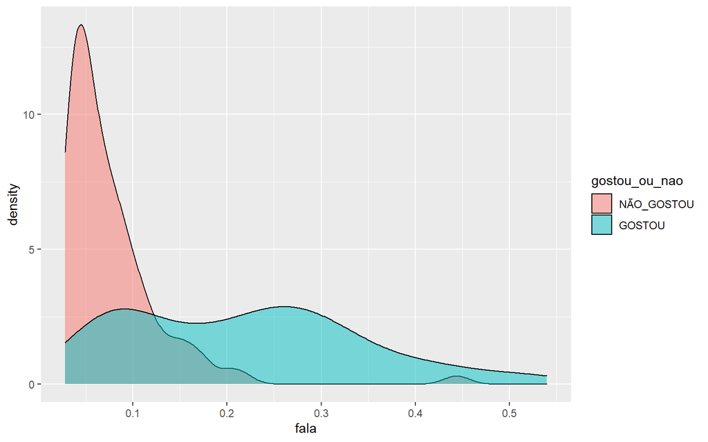

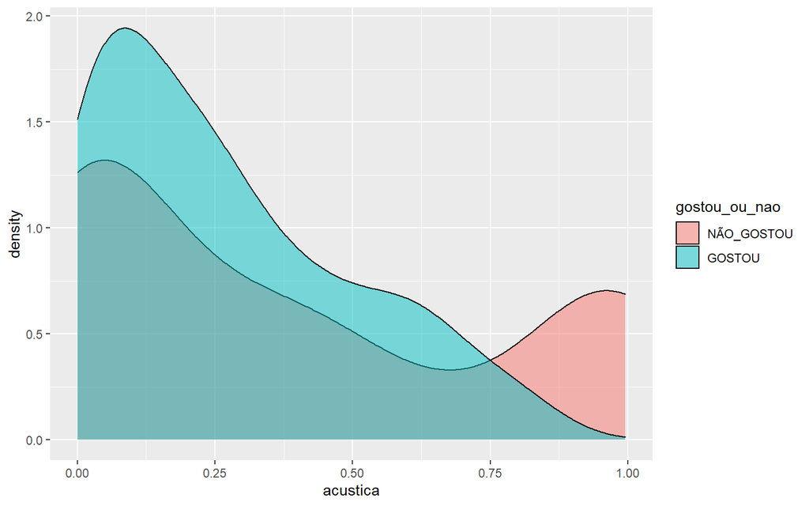

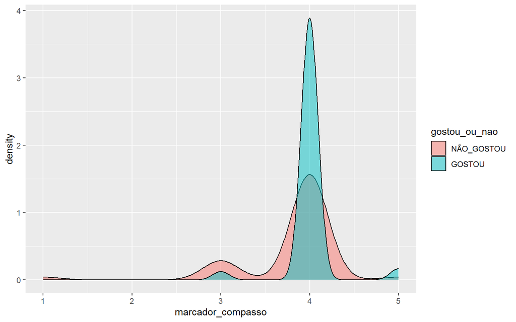

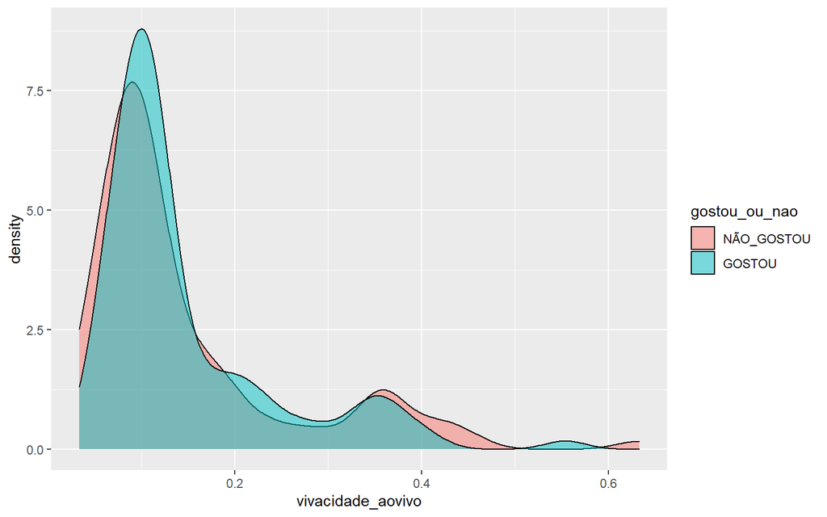

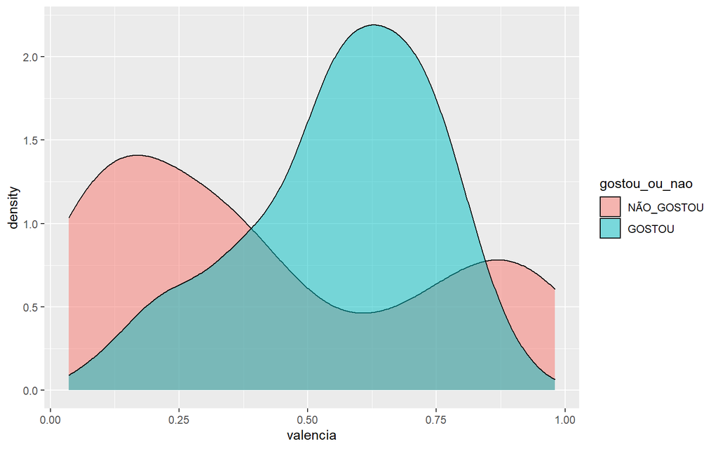

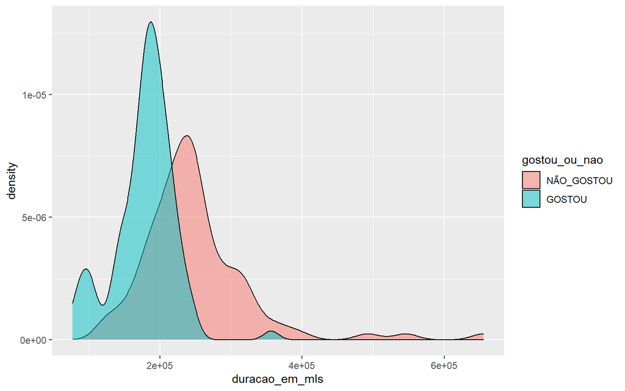

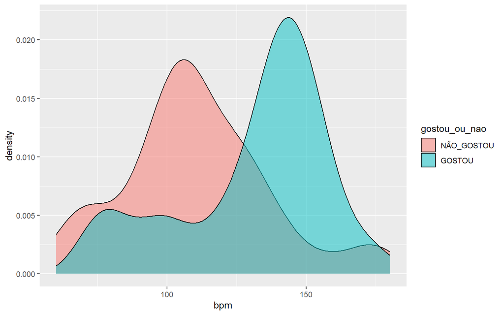

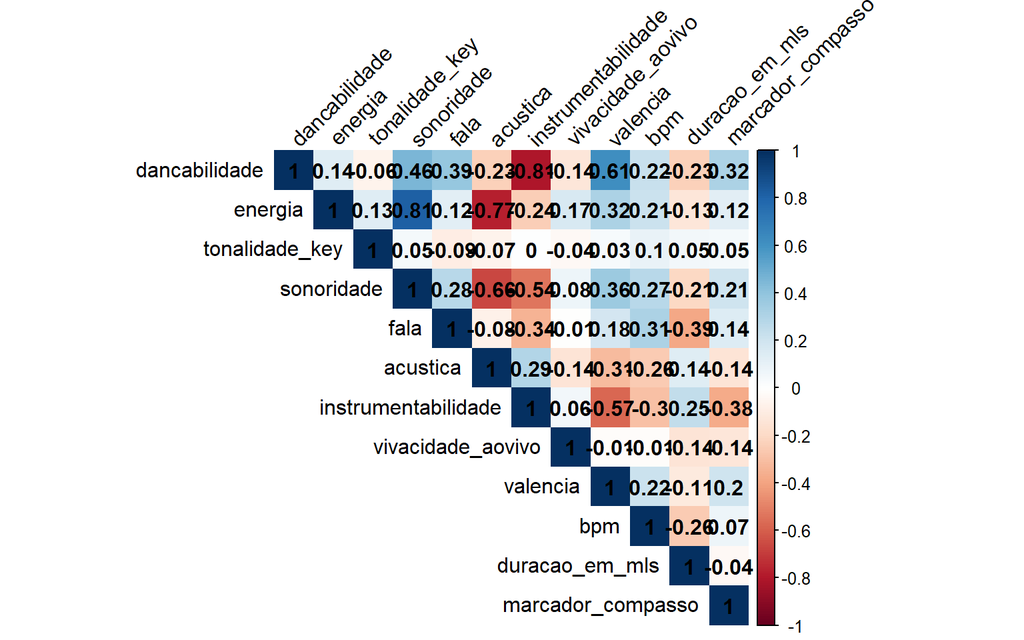